```r
library(ggplot2)
library(mgcv)
library(dplyr)
```

Читаем данные

```r
finch <- read.csv2("Data/RMR_Malaria_2020_parasitemia.csv")
finch$Experiment <- factor(finch$Experiment)
finch$Ring <- factor(finch$Ring)
```

Строим модель. Тут надо сильно думать, так как я не уверен, что правильно понял задачу.

Я понимаю ее так. Надо понять отличается ли RMR в трех группах Cont, Exp_1, Exp_2. Эти различия надо оценить на фоне изменения степени развития заболевания. Эта степень оценивается (1) временем со дня заражения и (2) долей зараженных эритроцитов. Оба этих показателя еще и взаимосвязаны. Это не очень хорошая история, так как коллинеарные предикторы могут маскировать друг друга. В этой ситуации их лучше объединить во что-то одно. Если не придумывать каких-то сложностей, то проще всего оценивать их влияние в качестве двумерной ковариаты. Но! эта двумерная ковариата влияет нелинейно на RMR. Поэтому ее лучше бы вставлять в GAM-модель в качестве двумерного смузера. при этом для Parasitemy, наверное, лучше бы использовать циклический сплайн.

Пока модель вижу вот так

```r
M1_gam <- gam(log(RMR) ~ s(dpi, Parasitemy, by = Experiment, bs = c("tp", "cc")) + Experiment + log(Mass) +  s(Ring, k = 53, bs = "re"),  method = "REML", data = finch)
```

Вот ее параметры

```r
summary(M1_gam)
```

```
##
## Family: gaussian
## Link function: identity
##
## Formula:
## log(RMR) ~ s(dpi, Parasitemy, by = Experiment, bs = c("tp", "cc")) +
##     Experiment + log(Mass) + s(Ring, k = 53, bs = "re")
##
## Parametric coefficients:
##                  Estimate Std. Error t value Pr(>|t|)
## (Intercept)      1.960647   0.257707   7.608 1.56e-12 ***
## ExperimentExp_1 -0.062661   0.027928  -2.244   0.0261 *
## ExperimentExp_2  0.008144   0.027771   0.293   0.7697
## log(Mass)        0.460016   0.100600   4.573 8.99e-06 ***
## ---
## Signif. codes:  0 '***' 0.001 '**' 0.01 '*' 0.05 '.' 0.1 ' ' 1
##
## Approximate significance of smooth terms:
##                                      edf Ref.df     F  p-value
## s(dpi,Parasitemy):ExperimentCont   3.326  4.126 2.128   0.0756 .
## s(dpi,Parasitemy):ExperimentExp_1 12.394 15.263 7.742  < 2e-16 ***
## s(dpi,Parasitemy):ExperimentExp_2  4.635  6.168 2.621   0.0182 *
## s(Ring)                           28.774 50.000 1.390 1.03e-05 ***
## ---
## Signif. codes:  0 '***' 0.001 '**' 0.01 '*' 0.05 '.' 0.1 ' ' 1
##
## Rank: 143/144
## R-sq.(adj) =  0.585   Deviance explained = 67.9%
## -REML = -182.54  Scale est. = 0.0066849  n = 231
```

```r
library(mgcViz)
b <- getViz(M1_gam)
```

Диагностика.

```
##
## Method: REML   Optimizer: outer newton
## full convergence after 6 iterations.
## Gradient range [-1.820591e-06,1.947205e-06]
## (score -182.5354 & scale 0.006684909).
## Hessian positive definite, eigenvalue range [0.2846411,112.7436].
## Model rank =  143 / 144
##
## Basis dimension (k) checking results. Low p-value (k-index<1) may
## indicate that k is too low, especially if edf is close to k'.
##
##                                      k'   edf k-index p-value
## s(dpi,Parasitemy):ExperimentCont  29.00  3.33    0.98    0.32
## s(dpi,Parasitemy):ExperimentExp_1 29.00 12.39    0.98    0.36
## s(dpi,Parasitemy):ExperimentExp_2 29.00  4.64    0.98    0.38
## s(Ring)                           53.00 28.77      NA      NA
```

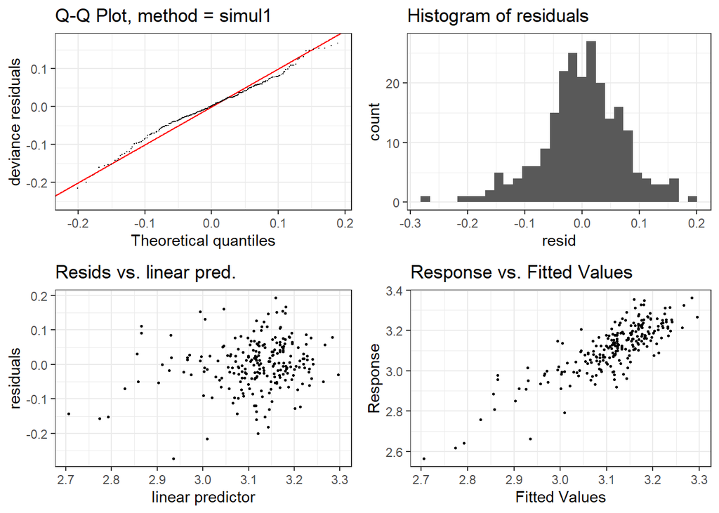

```r
check.gamViz(b)
```

Особых проблем не вижу. Есть намек на гетероскедастичность, но слабенький.

Вот ее визуализации. Немного кривые, но вполне читабельные.

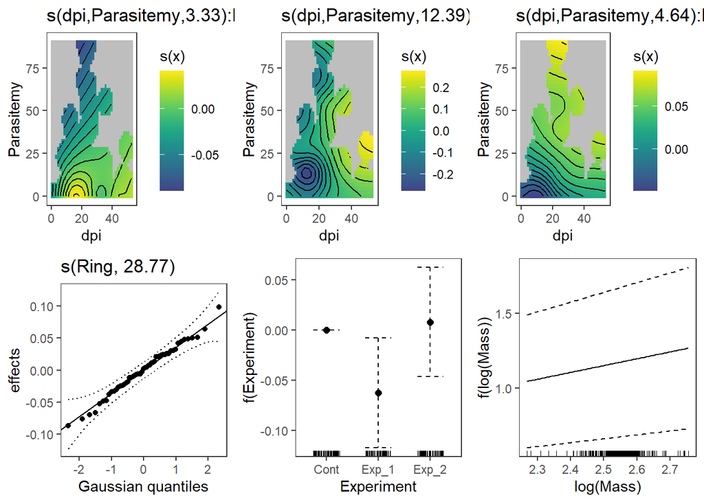

```r
br <- plot(b, allTerms = T)
print(br, pages = 1)
```